# Tiền xử lý dữ liệu trên R

Nguyễn Thị Phương Mai

2023-09-19

## 1. Véc tơ dữ liệu

### 1.1. Nhập dữ liệu dạng véc tơ

Để nhập một dữ liệu dạng véc tơ trong R, ta có thể dùng hàm *c* hoặc hàm *scan*. Giả sử ta có một véc tơ chỉ số lỗi chính tả trong $10$ trang sách đầu tiên của một cuốn sách:
$$2 \quad 3 \quad 0 \quad 5 \quad 1\quad 0
\quad 7\quad 0\quad 2\quad 7$$
Dữ liệu trên có thể được nhập vào R bằng hàm *c* như sau:

```r
SoLoi = c(2, 3, 0, 5, 1, 0, 7, 0, 2, 7)
SoLoi
```

```
##  [1] 2 3 0 5 1 0 7 0 2 7
```

```r
is.vector(SoLoi)
```

```
## [1] TRUE
```

Hoặc nhập bằng hàm *scan*:

```r
SoLoi = scan()
## (ENTER hai lần để kết thúc việc nhập dữ liệu)
SoLoi
```

```
## numeric(0)
```

```r
is.vector(SoLoi)
```

```
## [1] TRUE
```

Chú ý: Khi nhập dữ liệu bằng hàm c hoặc hàm *scan*, ta nên lưu ý sự khác biệt của hai hàm này như sau:

Hàm *c* có thể nhập dữ liệu dạng kí tự nhưng hàm scan chỉ nhập được dữ liệu dạng số.

```r
GioiTinh = c("Nam", "Nu", "Nu", "Nam")
GioiTinh
```

```
## [1] "Nam" "Nu"  "Nu"  "Nam"
```

```r
GioiTinh = scan()
```

*Hàm scan, trong một số trường hợp, giúp ta có thể copy dữ liệu từ những cột trong những tệp có sẵn từ excel file, text file,… nhưng ta không áp dụng được những thao tác kiểu này cho hàm* **c***.

### 1.2. Biên tập dữ liệu

Mỗi phần tử trong một véc tơ được xác định bởi địa chỉ là thứ tự của phần tử đó trong véc tơ. Ta có thể thay đổi, thêm vào hay bớt đi một số phần tử của véc tơ bằng cách truy cập vào địa chỉ của những phần tử đó. Chẳng hạn, trên véc tơ **SoLoi** ta có thể thực hiện:

```r
 ##Sao chép SoLoi sang SoLoi1
 SoLoi1 = SoLoi
 SoLoi1
```

```
## numeric(0)
```

```r
 ##Sửa số lỗi ở trang đầu tiên thành 1
 SoLoi1[1] = 1
 SoLoi1
```

```
## [1] 1
```

```r
 ##Sửa số lỗi trong trang 2,4,6
 SoLoi1[c(2,4,6)]=c(1,2,3)
 SoLoi1
```

```
## [1]  1  1 NA  2 NA  3
```

Ta cũng có thể thêm vào hay bớt đi một số phần tử của véc tơ:

```r
 SoLoi1[11:15] = c(1, 2, 0, 3, 1) ## thêm số lỗi của 5 trang sau
 SoLoi1
```

```
##  [1]  1  1 NA  2 NA  3 NA NA NA NA  1  2  0  3  1
```

```r
 SoLoi1[-(1:3)] ## bỏ ra khỏi véc tơ số lỗi 3 trang đầu tiên
```

```
##  [1]  2 NA  3 NA NA NA NA  1  2  0  3  1
```

hoặc cũng có thể ghép nhiều véc tơ dữ liệu lại với nhau:

```r
 SoLoi1 = SoLoi
 SoLoi2 = c(1, 4, 0, 5, 2, 3, 1, 0, 2, 5) ## Số lỗi trong 10 trang kế tiếp
 GhepSoLoi = c(SoLoi1, SoLoi2)
 GhepSoLoi
```

```
##  [1] 1 4 0 5 2 3 1 0 2 5
```

Tương tự, để ghép $n$ véc tơ dữ liệu có tên $x_1; x_2; ...; x_n$ lại với nhau theo thứ tự này, ta dùng hàm *c* như trên: $z = c(x1, x2,.., xn)$

Ngoài cách truy cập vào địa chỉ, ta có thể sửa, thêm, bớt phần tử của véc tơ bằng hàm *edit*. Chẳng hạn để biên tập véc tơ *SoLoi* và lưu kết quả vào véc tơ có tên *SoLoi3* ta làm như sau:

```r
SoLoi3=edit(SoLoi)
```

### 1.3. Truy cập dữ liệu

Để truy cập vào một véc tơ ta có thể tham khảo bảng lệnh sau:

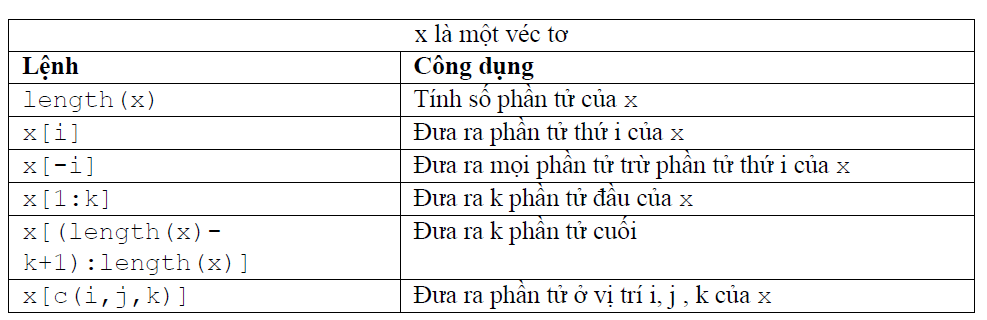

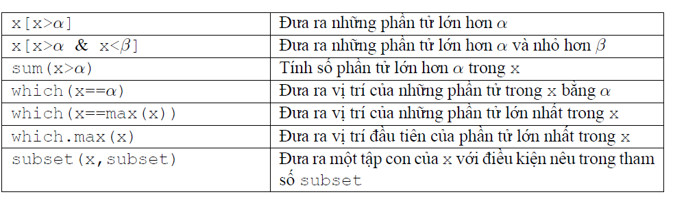

```r
 ##Số trang tìm lỗi
length(SoLoi)
```

```
## [1] 0
```

```r
 ##Số lỗi ở trang thứ 5
 SoLoi[5]
```

```
## [1] NA
```

```r
 ##Số lỗi ở trang 2, 5, 7
 SoLoi[c(2,5,7)]
```

```
## [1] NA NA NA
```

```r
 ##Những số lỗi lớn hơn 3
 SoLoi[SoLoi>3]
```

```
## numeric(0)
```

```r
 ##hoặc
subset(SoLoi,SoLoi>3)
```

```
## numeric(0)
```

```r
 ##Những số lỗi lớn hơn 3 và nhỏ hơn 6
SoLoi[SoLoi>3&SoLoi<6]
```

```
## numeric(0)
```

```r
##hoặc
 subset(SoLoi,SoLoi>3&SoLoi<6)
```

```
## numeric(0)
```

```r
 ##Số trang có số lỗi lớn hơn 3
 sum(SoLoi > 3)
```

```
## [1] 0
```

```r
 ##Những trang không có lỗi nào
 which(SoLoi == 0)
```

```
## integer(0)
```

```r
 ##Những trang có lớn hơn hay bằng 3 lỗi
 which(SoLoi >=3)
```

```
## integer(0)
```

```r
 ##Những trang có nhiều lỗi nhất
 which(SoLoi == max(SoLoi))
```

```
## integer(0)
```

```r
 ##Số lỗi lớn nhất
 ##Trang đầu tiên có nhiều lỗi nhất
 which.max(SoLoi == max(SoLoi))
```

```
## integer(0)
```

### 1.4. Loại bỏ số liệu trống

Trong trường hợp tập dữ liệu có chứa số liệu trống *NA* (Not Available) ta có thể loại những số liệu trống đó bằng hàm *na.omit*. Chẳng hạn, khi nhập thêm số lỗi của $5$ trang đánh máy tiếp theo nhưng số liệu thứ $13$ bị trống:

```r
SoLoi2 = c(1, 0, NA, 5, 2)
is.na(SoLoi2)
```

```
## [1] FALSE FALSE  TRUE FALSE FALSE
```

```r
sum(SoLoi2)
```

```
## [1] NA
```

Ta loại đi số liệu trống ở trang thứ $13$ như sau:

```r
SoLoi3 = na.omit(SoLoi2)
SoLoi3
```

```
## [1] 1 0 5 2
## attr(,"na.action")
## [1] 3
## attr(,"class")
## [1] "omit"
```

```r
sum(SoLoi3)
```

```
## [1] 8
```

### 1.5. Chuyển dữ liệu số thành dữ liệu định danh

Giả sử ta đánh giá về số lỗi của một trang đánh máy thành ba mức: ít (dưới $2$ lỗi), bình thường (từ $2$ đến $5$ lỗi), nhiều (trên $5$ lỗi). Ta tạo ra véc tơ định danh **PhanLoai** để mã hóa véc tơ **SoLoi** với ba mức **IT, BT, NHIEU** như sau:

```r
 SoLoi = c(2, 3, 0, 5, 1, 0, 7, 0, 2, 7)
 PhanLoai = SoLoi
 ##Trước khi mã hóa
 PhanLoai
```

```
##  [1] 2 3 0 5 1 0 7 0 2 7
```

```r
 ##Mã hóa
 PhanLoai[SoLoi < 2] = "IT"
 PhanLoai[SoLoi>= 2 & SoLoi <= 5] = "BT"
 PhanLoai[SoLoi > 5] = "NHIEU"
 ##Sau khi mã hóa
 PhanLoai
```

```
##  [1] "BT"    "BT"    "IT"    "BT"    "IT"    "IT"    "NHIEU" "IT"    "BT"
## [10] "NHIEU"
```

Ta có thể kết hợp hai véc tơ **SoLoi** và **PhanLoai** thành một bảng dữ liệu (data frame) bằng hàm *data.frame*:

```r
data.frame(SoLoi,PhanLoai)
```

```
##    SoLoi PhanLoai
## 1      2       BT
## 2      3       BT
## 3      0       IT
## 4      5       BT
## 5      1       IT
## 6      0       IT
## 7      7    NHIEU
## 8      0       IT
## 9      2       BT
## 10     7    NHIEU
```

### 1.6. Biến đổi véc tơ định danh thành véc tơ nhân tố

Véc tơ **PhanLoai** trên đây là một véc tơ định danh với giá trị là những xâu kí tự. Để chuyển véc tơ **PhanLoai** này thành véc tơ lưu dữ liệu dạng thứ bậc, ta dùng hàm *factor*:

```r
PhanLoai = factor(PhanLoai, level=c("IT", "BT", "NHIEU"))
PhanLoai
```

```
##  [1] BT    BT    IT    BT    IT    IT    NHIEU IT    BT    NHIEU
## Levels: IT BT NHIEU
```

## 2. Bảng Dữ liệu

### 2.1. Nhập dữ liệu dạng bảng

Giả sử ta có một tập dữ liệu dạng bảng cho thông tin về chiều cao, cân nặng và giới tính của 5 sinh viên như sau:

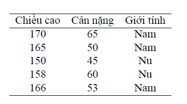

Dữ liệu trên có thể được nhập thành một bảng (data frame) trong R bằng cách nhập từng cột vào một véc tơ rồi ghép chúng lại với nhau bằng hàm *data.frame*:

*data.frame(…, row.names, stringsAsFactors)*

trong đó

**…:** tên các cột của bảng dữ liệu.

**row.names:** tên các dòng.

**stringsAsFactors:** tham số logic, TRUE/FALSE tương ứng có/không chuyển các biến kiểu xâu kí tự thành yếu tố.

```r
ChieuCao = c(170, 165, 150, 158, 166)
CanNang = c(65, 50, 45, 60, 53)
GioiTinh = c("Nam", "Nam", "Nu", "Nu", "Nam")
DuLieu = data.frame(ChieuCao, CanNang, GioiTinh)
View(DuLieu)
is.data.frame(DuLieu)
```

```
## [1] TRUE
```

Ngoài cách trên ta có thể nhập dữ liệu vào bảng dữ liệu trong R bằng cách sử dụng hàm *edit*. Để nhập dữ liệu theo cách này, tại cửa sổ dòng lệnh ta gõ lệnh:

```r
#DuLieu = edit(data.frame())
#View(DuLieu)
```

Để nhập dữ liệu, chẳng hạn cho cột **ChieuCao**, đầu tiên nhấp chuột vào ô **var1** để mở cửa sổ **Variable editor**, tại cửa sổ này chọn tên cột và kiểu dữ liệu cho cột:

- Chọn **variable name** là **ChieuCao**;
- Chọn type là **numeric**.

và sau đó nhập dữ liệu vào trong các ô của cột. Nhập dữ liệu cho các cột còn lại cũng được tiến hành tương tự. Để kết thúc việc nhập dữ liệu, ta đóng cửa sổ biên tập dữ liệu và khi đó trong cửa sổ dòng lệnh **R Console** đã có một đối tượng tên là *DuLieu*.

### 2.2. Biên tập dữ liệu

Trong một bảng dữ liệu, mỗi dòng, mỗi cột đều được xác định bởi địa chỉ là thứ tự hoặc tên của dòng, cột đó. Địa chỉ của mỗi ô trong bảng dữ liệu được xác định bởi địa chỉ của dòng và cột chứa ô đó. Địa chỉ của dòng, cột, ô được khai báo trong kí hiệu [,]. Sau đây ta minh họa một số thao tác thay đổi, thêm bớt dữ liệu trên bảng *DuLieu*.

```r
DuLieu1=DuLieu
##Đổi tên cho các cột bằng hàm colnames hoặc names
colnames(DuLieu1) = c("CC","CN","GT")
View(DuLieu1)
```

```r
##Đặt tên cho các dòng bằng hàm rownames
rownames(DuLieu1) = c("Vu", "Hieu", "Hoa", "Thuy", "Nam")
View(DuLieu1)
```

```r
## Sửa chiều cao của sinh viên thứ 3 thành 160 (sửa ô ở dòng 3, cột 1)
DuLieu[3,1]=160
View(DuLieu)
```

Như đã nói trên, địa chỉ **DuLieu[3,1]** có thể khai báo theo những cách khác: **DuLieu[“3”,“ChieuCao”]** hoặc **DuLieu[3,“ChieuCao”]** hoặc **DuLieu[“3”,1]**.

Khi muốn thêm vào bảng dữ liệu một số cột, chẳng hạn thêm cột quê quán và tuổi của 5 sinh viên nói trên, ta làm như sau:

```r
##Nhập dữ liệu cột quê quán và cột tuổi
QueQuan = c("HaNoi", "QuangNinh", "NgheAn", "NamDinh", "LangSon")
Tuoi = c(23, 22, 20, 25, 19)
## Ghép hai cột quê quán và tuổi vào bảng dữ liệu
DuLieu2 = data.frame(DuLieu, QueQuan, Tuoi)
View(DuLieu2)
```

Hoặc ta cũng có thể ghép thêm cột vào bảng dữ liệu theo cách sau:

```r
DuLieu[,4:5] = c(QueQuan, Tuoi)
View(DuLieu)
```

sau đó đổi tên hai cột cuối:

```r
colnames(DuLieu)[4:5]=c("QueQuan", "Tuoi")
View(DuLieu)
```

Việc thêm một số dòng vào bảng dữ liệu được làm tương tự như đối với cột. Ngoài ra, ta có thể thực hiện việc thêm cột hay dòng vào bảng dữ liệu nhờ hàm **cbind** (cho cột) và **rbind** (cho dòng). Cách dùng hai hàm này được minh họa qua đoạn lệnh sau:

```r
DuLieu = data.frame(ChieuCao, CanNang, GioiTinh)
##Ghép thêm cột quê quán và tuổi
DuLieu2 = cbind(DuLieu, QueQuan, Tuoi)
View(DuLieu2)
DuLieuThem=data.frame(ChieuCao =c(150,170),CanNang=c(48,70),GioiTinh=c("Nu","Nam"),QueQuan=c("CaoBang","HaNoi"),Tuoi=c(21,19))
View(DuLieuThem)
DuLieu3 = rbind(DuLieu2, DuLieuThem)
View(DuLieu3)
```

Sử dụng địa chỉ của ô, dòng, cột để thay đổi, thêm hoặc bớt dữ liệu vào bảng rất tiện lợi đối với những bảng dữ liệu cỡ lớn. Đối với bảng dữ liệu cỡ nhỏ, ta có thể sử dụng hàm **edit** hoặc dùng hàm **fix** để thực hiện các thao tác trên. Chẳng hạn, để sửa bảng DuLieu, ta làm như sau:

```r
#DuLieu3 = edit(DuLieu)
#Hoặc
#DuLieu3=fix(DuLieu)
```

### 2.3. Truy cập dữ liệu

Trong phần này, ta sẽ thực hiện các thao tác trên bảng dữ liệu **DuLieu** để minh họa cách truy cập vào một bảng dữ liệu trong R. Ta có thể tham khảo một số lệnh cơ bản trong bảng sau:

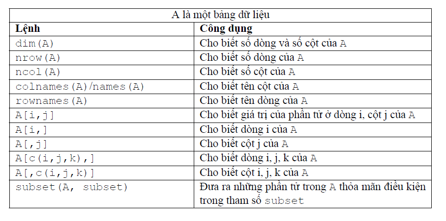

Đoạn lệnh sau cho một số thông tin của nhóm sinh viên khi truy cập vào bảng **DuLieu**.

```r
##Tên các cột
names(DuLieu)
```

```
## [1] "ChieuCao" "CanNang"  "GioiTinh"
```

```r
##Số dòng và số cột
dim(DuLieu)
```

```
## [1] 5 3
```

```r
##Chiều cao của sinh viên thứ 4
DuLieu[4,1]
```

```
## [1] 158
```

```r
## Dữ liệu về sinh viên thứ 3
DuLieu[3,]
```

```
##   ChieuCao CanNang GioiTinh
## 3      150      45       Nu
```

```r
##Thông tin về sinh viên thứ 2 và thứ 5
DuLieu[c(2,5),]
```

```
##   ChieuCao CanNang GioiTinh
## 2      165      50      Nam
## 5      166      53      Nam
```

```r
##Thông tin về giới tính của nhóm sinh viên
DuLieu[,3]
```

```
## [1] "Nam" "Nam" "Nu"  "Nu"  "Nam"
```

Ngoài ra, ta có thể sử dụng toán tử $ hoặc hàm **attach** để lấy ra các cột của dữ liệu như sau:

```r
##Thông tin về giới tính của nhóm sinh viên
##GioiTinh
DuLieu$GioiTinh
```

```
## [1] "Nam" "Nam" "Nu"  "Nu"  "Nam"
```

```r
attach(DuLieu)
ChieuCao
```

```
## [1] 170 165 150 158 166
```

Ta cũng có thể đưa ra những phần tử trong bảng dữ liệu thỏa mãn một hoặc một số điều kiện nào đó bằng cách sử dụng hàm **subset**. Chẳng hạn để lấy dữ liệu về những sinh viên nữ, ta thực hiện:

```r
subset(DuLieu,GioiTinh == "Nu")
```

```
##   ChieuCao CanNang GioiTinh
## 3      150      45       Nu
## 4      158      60       Nu
```

```r
subset(DuLieu,GioiTinh=="Nam"&ChieuCao>160)
```

```
##   ChieuCao CanNang GioiTinh
## 1      170      65      Nam
## 2      165      50      Nam
## 5      166      53      Nam
```

```r
DuLieu[GioiTinh == "Nam" & ChieuCao > 160,]
```

```
##   ChieuCao CanNang GioiTinh
## 1      170      65      Nam
## 2      165      50      Nam
## 5      166      53      Nam
```

```r
#Sử dụng hàm attach để lấy từng cột của dữ liệu như lấy ra một dữ liệu:
attach(DuLieu)
GioiTinh
```

```
## [1] "Nam" "Nam" "Nu"  "Nu"  "Nam"
```

```r
DuLieu[GioiTinh == "Nam" & ChieuCao > 160,]
```

```
##   ChieuCao CanNang GioiTinh
## 1      170      65      Nam
## 2      165      50      Nam
## 5      166      53      Nam
```

### 2.4. Loại bỏ số liệu trống

Tương tự trường hợp dữ liệu dạng véc tơ, hàm **na.omit** được dùng để loại đi số liệu trống **(NA)** trong bảng dữ liệu. Chẳng hạn ta có bảng dữ liệu:

```r
DuLieuMoi=data.frame(ChieuCao=c(170,NA,150,158,166,160),CanNang=c(65,50,45,60,53,50),GioiTinh=c("Nam","Nam","Nu","Nu","Nam",NA))
View(DuLieuMoi)
```

Ta loại đi dữ liệu trống trong bảng:

```r
DuLieuMoi1=na.omit(DuLieuMoi)
View(DuLieuMoi1)
```

và kết quả cho ta thấy R loại bỏ toàn bộ dòng chứa dữ liệu trống.

Để thống kê số lượng ô bị thiếu dữ liệu ở từng cột, chúng ta sử dụng hàm **is.na()** và hàm **colSums()**:

```r
is.na(DuLieuMoi)
```

```
##      ChieuCao CanNang GioiTinh
## [1,]    FALSE   FALSE    FALSE
## [2,]     TRUE   FALSE    FALSE
## [3,]    FALSE   FALSE    FALSE
## [4,]    FALSE   FALSE    FALSE
## [5,]    FALSE   FALSE    FALSE
## [6,]    FALSE   FALSE     TRUE
```

```r
colSums(is.na(DuLieuMoi))
```

```
## ChieuCao  CanNang GioiTinh
##        1        0        1
```

Để thay thế dữ liệu định lượng bị thiếu bằng các giá trị khác (ví dụ: giá trị trung bình), ta sử dụng các hàm của R để làm việc này:

```r
DuLieuMoi$ChieuCao[is.na(DuLieuMoi$ChieuCao)]=mean(DuLieuMoi$ChieuCao,na.rm=TRUE)
View(DuLieuMoi)
```

### 2.5. Tạo dữ liệu

R cung cấp rất nhiều hàm tạo dữ liệu theo những yêu cầu nhất định. Trong mục này, ta giới thiệu một số hàm tạo dữ liệu đơn giản hay sử dụng trong R như: **seq, rep,** .

#### 2.5.1.Tạo dãy số cách đều bằng hàm *seq*

Để tạo dãy số cách đều ta có thể dùng hàm seq bằng những cách sau:

**seq(from, to, by),**

**seq(length, from, by)**

**seq(length, from, to)**

trong đó

**from**: giá trị bắt đầu của dãy số.

**to**: giá trị chặn trên của dãy số.

**by**: khoảng cách giữa các số trong dãy.

**length**: số phần tử của dãy số.

```r
## Tạo một dãy số từ 2 đến 5 cách nhau 0.5
seq(from = 2, to = 5, by = 0.5)
```

```
## [1] 2.0 2.5 3.0 3.5 4.0 4.5 5.0
```

```r
## hoặc
seq(2, 5, 0.5)
```

```
## [1] 2.0 2.5 3.0 3.5 4.0 4.5 5.0
```

```r
## Tạo một dãy số xuất phát từ 2, bị chặn trên bởi 5.3, cách nhau 0.5
seq(2, 5.3, 0.5)
```

```
## [1] 2.0 2.5 3.0 3.5 4.0 4.5 5.0
```

```r
## Tạo một dãy số độ dài 8, bắt đầu từ 4 cách nhau 3
seq(length = 8, from = 4, by = 3)
```

```
## [1]  4  7 10 13 16 19 22 25
```

```r
## Tạo một dãy số độ dài 5, cách đều nhau từ 4 đến 6
seq(length = 5, from = 4, to = 6)
```

```
## [1] 4.0 4.5 5.0 5.5 6.0
```

Khi các phần tử trong dãy cách nhau 1, ta có thể làm như sau:

```r
seq(1,10)
```

```
##  [1]  1  2  3  4  5  6  7  8  9 10
```

```r
##hoặc
1:10
```

```
##  [1]  1  2  3  4  5  6  7  8  9 10
```

#### 2.5.2.Tạo dãy lặp lại bằng hàm *rep*

**rep(x,times)**

trong đó

**x**: véc tơ các giá trị được lặp lại.

**times**: véc tơ chỉ số lần lặp lại.

```r
##Tạo dãy số 8 lặp 5 lần
rep(8, times = 5)
```

```
## [1] 8 8 8 8 8
```

```r
##Tạo dãy số 1,2,3,4 lặp lại 3 lần
rep(1:4, times = 3)
```

```
##  [1] 1 2 3 4 1 2 3 4 1 2 3 4
```

```r
##Tạo dãy số 1,2,3,4, mỗi số lặp lại 3 lần
rep(1:4, each=3)
```

```
##  [1] 1 1 1 2 2 2 3 3 3 4 4 4
```

```r
##Tạo dãy chữ cái trong đó chữ a lặp 2 lần, chữ b lặp 3 lần, chữ c lặp 4 lần
rep(c("a","b","c"),c(2,3,4))
```

```
## [1] "a" "a" "b" "b" "b" "c" "c" "c" "c"
```

### 2.6. Đọc dữ liệu

#### 2.6.1. Nhập dữ liệu trực tiếp

```r
age <- c(50, 62, 60, 40, 48, 47, 57, 70, 48)
insulin <- c(16.5, 10.8, 32.3, 19.3, 14.2, 11.3, 15.5, 15.8, 16.2)
data = data.frame(age,insulin)
data
```

```
##   age insulin
## 1  50    16.5
## 2  62    10.8
## 3  60    32.3
## 4  40    19.3
## 5  48    14.2
## 6  47    11.3
## 7  57    15.5
## 8  70    15.8
## 9  48    16.2
```

```r
View(data)
```

#### 2.6.2. Nhập dữ liệu từ Excel (File.csv)

Khi nhập dữ liệu vào excel, thông thường tệp chứa dữ liệu có đuôi .xls, để đọc những tệp này từ R ta làm như sau

- Trước hết ta lưu tệp dưới dạng đuôi **.csv**.
- Đọc tệp có phần đuôi **.csv** từ R bằng hàm **read.csv**

**read.csv(link, header)**

trong đó

**link**: đường link thư mục lưu trữ tệp dữ liệu dạng file.csv.

**header**: tham số logic TRUE/FALSE chỉ dòng đầu tiên trong dữ liệu có/không phải tên của các cột, mặc định header = TRUE.

```r
#FastFood=read.csv("E:\Teaching\Introduction to data analysis\Lectures 2023-2024\Dữ liệu trong bài giảng\fastfood.csv",header=T)
#View(FastFood)
```

### 2.6.3. Nhập dữ liệu từ file Excel (File.xlsl)

```r
#library(readxl)
#FastFood= read_excel("E:/Teaching/Introduction to data analysis/Lectures 2023-2024/Dữ liệu trong bài giảng/fastfood.xlsx")
#View(FastFood)
```

#### 2.6.4. Đọc dữ liệu từ packages

```r
#library(MASS)
#Boston=Boston
#View(Boston)
```

### 2.7. Lưu dữ liệu

Ngoài ra, R có rất nhiều hàm giúp chúng ta lưu dữ data frame dưới các định dạng tệp khác nhau ** file rda,csv,xlsx:**

```r
##Chọn thư mục để lưu dữ liệu
#setwd("E:/Teaching/Introduction to data analysis/Lectures 2023-2024/Dữ liệu trong bài giảng")
##Thực hiện lưu dữ liệu
#save(Boston, file = "Boston.rda")
```

```r
#write.csv(Boston, "Boston.csv")
```

Ngoài ra chúng ta có thể xuất file dưới định dạng .xlsx bằng lệnh “write_xlsx()” nằm trong gói “writexl”.

```r
##install.packages("writexl")
#library(writexl)
#write_xlsx(Boston,"Boston.xlsx")
```

###2.8. Mã hóa dữ liệu định tính

Lấy dữ liệu **mtcars** trong tạp chí Motor Trend US 1974. Trong dữ liệu này, biến “am” là kiểu hộp số được mã hóa với 2 giá trị 0 (automatic), 1(manual). Chúng ta sẽ mã hóa lại biến số am thành dạng nhân tố (factor) với tên lần lượt là “automatic” và “manual” và gán cho một biến số mới có tên là “trans”.

```r
data=mtcars
is.numeric(data$am)
```

```
## [1] TRUE
```

```r
data$trans=factor(data$am, levels=c(0,1),labels=c("Automatic","Manual"))
View(data)
```

###2.9. Rời rạc hóa dữ liệu định lượng

Giả sử chúng ta muốn rời rạc hóa dữ liệu công suất của 32 dòng ô tô thành 3 nhóm: cao (H), trung bình (M), thấp (L) và gán các giá trị này vào một biến số mới có tên “power”. Ta sử dụng hàm **cut**:

```r
data$power = cut(data$hp, breaks=c(-Inf, 96.5, 180, Inf), labels=c("L","M","H"))
View(data)
```

### 2.10. Chọn mẫu ngẫu nhiên

Khi muốn thực hiện phép chọn mẫu ngẫu nhiên, ta dùng hàm **sample** với những tham số chính như sau:

**sample(x, size, replace, prob)**

trong đó

*x:* véc tơ gồm những phần tử dùng để chọn mẫu, hoặc một số nguyên dương.

*size:* số nguyên dương chỉ số phần tử trong mẫu.

*replace:* tham số logic, TRUE/FALSE chỉ việc chọn mẫu có/không hoàn lại, mặc định replace=FALSE.

*prob* véc tơ cho biết xác suất được chọn của những phần tử trong x.

Đoạn lệnh sau cho ta một số kết quả chọn ngẫu nhiên ra 10 phần tử từ tổng thể gồm 200 phần tử được đánh số từ 1 tới 200:

```r
##Chọn mẫu gồm 10 phần tử từ 200 phần tử
sample(1:200, 10)
```

```
##  [1]  49 144   6   3  47   4  13 133  33  40
```

```r
##Chọn mẫu khác gồm 10 phần tử từ 200 phần tử
sample(1:200, 10)
```

```
##  [1] 145  25 200 148  50   5  58  70  45  46
```

```r
##Chọn mẫu gồm 10 phần tử có hoàn lại từ 200 phần tử
sample(1:200, 10, replace=T)
```

```
##  [1] 176  16  78 148  79  61  69  82 197 130
```

Giả sử ta có một hộp gồm 3 quả bóng: xanh (X), đỏ (D), vàng (V). Tiến hành chọn (có hoàn lại) ngẫu nhiên 5 quả bóng, kết quả có thể là:

```r
sample(c("X","D","V"), 5, replace=T)
```

```
## [1] "V" "V" "D" "V" "V"
```

Chọn ra 5 phần tử từ tổng thể gồm 3 phần tử mà xác suất được chọn của chúng lần lượt là 0.5,0.3 và 0.2:

```r
sample(3, 5, prob=c(0.5,0.3,0.2), replace=T)
```

```
## [1] 3 1 1 1 3
```

Chú ý:

- Vì việc chọn mẫu là ngẫu nhiên nên có thể cùng một lệnh chọn mẫu nhưng với những lần chọn khác nhau cho ta kết quả là khác nhau. Trong trường hợp muốn cố định mẫu được chọn để dùng lại trong các lần sau, ta dùng hàm **set.seed(n)**, trong đó **n** là một số nguyên dương dùng để cố định mẫu.

```r
##Đặt tên mẫu
set.seed(20100612)
sample(1:200, 10)
```

```
##  [1]  46   7  27  97  62 162  83  99  42 135
```

```r
##Không gọi lại tên mẫu, kết quả là một mẫu khác
sample(1:200, 10)
```

```
##  [1] 124 172  44  76 126  50  61  23  91 104
```

```r
##gọi lại tên mẫu và được mẫu như cũ
set.seed(20100612)
sample(1:200, 10)
```

```
##  [1]  46   7  27  97  62 162  83  99  42 135
```

- Hàm sample cho ta cách chọn mẫu từ một véc tơ. Trong trường hợp muốn chọn mẫu từ một nhóm đối tượng có dữ liệu chứa trong một bảng dữ liệu, đầu tiên ta áp dụng hàm **sample** cho véc tơ chỉ số thứ tự của các đối tượng, sau đó lấy từ bảng ra những quan sát có thứ tự đã chọn được.

Chẳng hạn với bảng **DuLieu** gồm thông tin của 5 sinh viên cho trong phần trước, để chọn ngẫu nhiên ra 3 sinh viên từ bảng này, ta thực hiện như sau:

```r
View(DuLieu)
##Chọn thứ tự các sinh viên trong mẫu
Mau = sample(1:5, 3)
Mau
```

```
## [1] 4 1 2
```

```r
##Lấy ra những sinh viên với thứ tự trong mẫu
DLMau = DuLieu[Mau, ]
View(DLMau)
```

### 2.11. Lập trình cơ bản trong R

#### 2.11.1. Câu lệnh If

**if (test_expression){**

**statement**

**}** Cho trước $x$. Kiểm tra xem $x$ có là số dương hay không?

```r
x=7
if(x>0){
  print("x là Số dương")
}
```

```
## [1] "x là Số dương"
```

#### 2.11.2. Câu lệnh If…else

**if (test_expression){**

**statement1**

**} else {**

**statement2**

**}** Cho trước $x$. Kiểm tra xem $x$ là số không âm hay số âm?

```r
x=-7
if(x>=0){
  print("x là số không âm")
}else{
  print("x là số âm")
}
```

```
## [1] "x là số âm"
```

#### 2.11.3. Câu lệnh If…else Ladder

**if (test_expression){**

**statement1**

**} else if {**

**statement2**

**} else if (test_expression3){**

**statement3**

**} else {**

**statement4**

**}** Cho trước $x$. Kiểm tra xem $x$ là số dương, số âm hay bằng 0?

```r
x=7
if (x>0){
  print("x là số dương")
} else if (x==0){
  print("x bằng 0")
} else {
  print("x là số âm")
}
```

```
## [1] "x là số dương"
```

### 2.11.2. Vòng lặp for

** for ( value in sequence)**

**{**

**statement**

```r
x=1:5
for ( i in 1:length(x)){
  print(x[i])
}
```

```
## [1] 1
## [1] 2
## [1] 3
## [1] 4
## [1] 5
```

```r
x=sample(c(2,7,4,6), 10, replace = TRUE)
y=sample(20:50, 10, replace = TRUE)
```

### 2.11.2. Câu lệnh while

**while (condition) {**

**statement**

**}**

### 2.11.3. Viết hàm trong R

**tenham = function() {**

**Nội dung của hàm**

**}**

### 2.11.4. Họ hàm apply và ifelse trong R

Trong R, ngoài việc sử dung vòng for để thực hiện thao tác lặp, ta còn có thể sử dụng các hàm **apply() , lapply() , sapply()**.

Ưu điểm lớn nhất của các hàm này so với sử dụng vòng lặp **for** là giúp code trở nên ngắn gọn hơn.

Hàm **apply()** có cấu trúc như sau:

**apply(X, MARGIN, FUN)**

Trong đó:

Trong đó:

- X là một vector hoặc matrix.
- MARGIN: Nếu MARGIN = 1 thì hàm sẽ áp dụng với từng hàng, MARGIN = 2 thì sẽ áp dụng hàm với từng cột.
- FUN: tên của hàm mà ta muốn áp dụng, có thể tự định nghĩa.

Tính tổng các hàng của ma trận:

```r
A = matrix(1:10, nrow=3, ncol=10)
A
```

```
##      [,1] [,2] [,3] [,4] [,5] [,6] [,7] [,8] [,9] [,10]
## [1,]    1    4    7   10    3    6    9    2    5     8
## [2,]    2    5    8    1    4    7   10    3    6     9
## [3,]    3    6    9    2    5    8    1    4    7    10
```

```r
apply( A,1,sum)
```

```
## [1] 55 55 55
```

Hàm **lapply()** có cấu trúc như sau:

**lapply(X, FUN)**

Lưu ý rằng hàm **lapply()** luôn trả về kết quả là 1 list.

```r
names <- c("priyank", "abhiraj","pawananjani", "sudhanshu","devraj")
lapply(names, toupper)
```

```
## [[1]]
## [1] "PRIYANK"
##
## [[2]]
## [1] "ABHIRAJ"
##
## [[3]]
## [1] "PAWANANJANI"
##
## [[4]]
## [1] "SUDHANSHU"
##
## [[5]]
## [1] "DEVRAJ"
```

Hàm **sapply()** có cấu trúc như sau:

**sapply(X, FUN)**

Với các tham số tương tự như hàm **lapply()**.

Điểm khác biệt của hàm trên so với hàm **lapply()** là hàm trả về vector hoặc matrix.

```r
sample_data <- data.frame(
x=c(1,2,3,4,5,6),
y=c(3,2,4,2,34,5)
)
sapply(sample_data, max)
```

```
##  x  y
##  6 34
```

```r
sapply(sample_data, function(data) {
return(max(data) - 2*min(data))
})
```

```
##  x  y
##  4 30
```

Ngoài ra, trong R còn có hàm **ifelse()** như sau:

**ifelse(test, yes, no)**

Trong đó:

- test là 1 biểu thức điều kiện.
- yes là giá trị trả về nếu điều kiện đúng.
- no là giá trị trả về nếu điều kiện sai.

Ưu điểm của hàm **ifelse()**:

- Thay thế cho cấu trúc if…else khi điều kiện đơn giản.
- Hàm có tính vectơ hóa.

```r
a = c(5,7,2,9)
ifelse(a %% 2 == 0,"even","odd")
```

```
## [1] "odd"  "odd"  "even" "odd"
```